# CFPB zip

T Morrison

May 26, 2016

Continuing with the CFPB data from the previous two posts, I am now going to look at some variations of the data by location.

### Demographics

Before diving into the map visualizations, I want to check out one variable I haven’t looked at- `tags`

```r
x[,.N, by=tags]
```

```
##                             tags      N
## 1:                            NA 477998
## 2:                Older American  45257
## 3:                 Servicemember  26335
## 4: Older American, Servicemember   6367
```

What are older Americans’ and servicemembers’ complaints about?

First, I want to set up a proportional variable to view how the number of complaints by `product` compares to the total number of complaints for each type in `tags`; I’ll also set tha `NA`s in `tags` to “Other”.

```r
x[is.na(x$tags)]$tags <- "Other"
y <- x[, .N, by=.(tags, product)]
y$prop <- ifelse(y$tags=="Other", y$N/405442,
                 ifelse(y$tags=="Older American", y$N/37314,
                        ifelse(y$tags=="Older American, Servicemember", y$N/5256,
                               ifelse(y$tags=="Servicemember", y$N/20610, NA))))
```

Now, a nice barplot. I’m leaving out “Older American, Servicemember” because there are so few observations there.

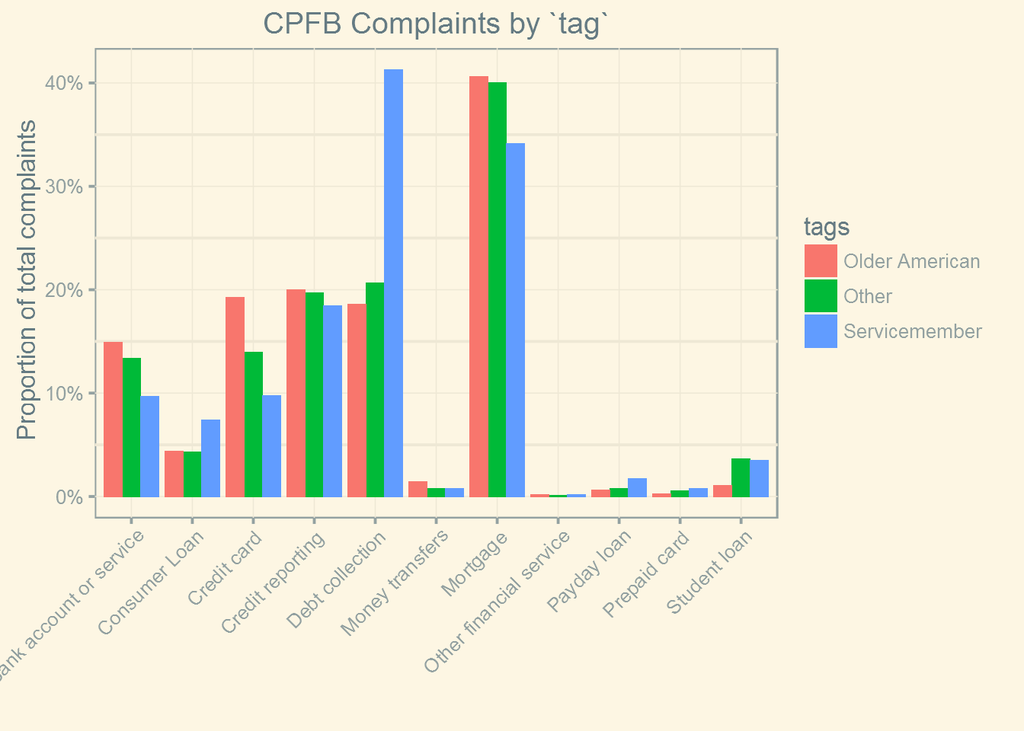

```r
ggplot(y[tags!="Older American, Servicemember"], aes(x=product, y=prop, fill=tags)) +
  geom_bar(stat="identity", position="dodge") +
  scale_y_continuous(labels=scales::percent) +
  theme_solarized() +
  theme(axis.text.x=element_text(angle=45, hjust=1)) +
  theme(strip.background=element_rect(fill=NA)) +
  ggtitle("CPFB Complaints by `tag`") + xlab("") + ylab("Proportion of total complaints")
```

### Maps

To use the zipcode data from the CFPB dataset in a map, I needed to get some location identifiers for those zipcodes. Luckily, the `zipcode` package contains a dataset, `zipcode`, that has longititude and latitude attributes for each zipcode in the US. I merged this with my CFPB dataset below. I also removed all the non-continental observations to help with the mapping (Alaska, Puerto Rico, etc.).

```r
data(zipcode)
zipcode <- as.data.table(zipcode)
zipcode$zip <- as.numeric(zipcode$zip)

x <- merge(x, zipcode, by.x='zipcode', by.y='zip')
x<-x[state.x !="HI"]
x<-x[state.x !="PR"]
x<-x[state.x !="AS"]
x<-x[state.x !="GU"]
x<-x[state.x !="MP"]
x<-x[state.x !="VI"]
x<-x[state.x !="AK"]
x<-x[state.y !="AK"]
x<-x[state.y !="HI"]
x<-x[state.y !="PR"]
```

The base map will be made using the shapefiles from the `ggplot2` dataset `"state"`, loaded using the `map_data()` function.

A look at all the observations on a map of the US is not very helpful, since the 400k+ observations essentially paint the map solid in the populated areas of the country

Going down to a single product, we may reveal some more interesting geographical patterns. There are about 13,000 student loan complaints in the dataset.

Before starting, I have created a new dataset with the `ggplot2` function `geocode()`. This useful function allows you to get the coordinates (lat/long) for any city or address you type. I am using it to put in some of the major cities in the US.

```r
cityName <- c("Boston", "New York", "Chicago","Dallas", "Los Angeles","San Francisco","Seattle","Portland","Detroit","Austin","Denver", "Washington, DC", "St. Louis", "Houston", "Atlanta","Philadelphia", "Miami", "Phoenix")
bigCity <- geocode(c("Boston", "New York", "Chicago","Dallas", "Los Angeles","San Francisco","Seattle","Portland","Detroit","Austin","Denver", "Washington, DC", "St. Louis", "Houston", "Atlanta","Philadelphia", "Miami","Phoenix"))
bigCity <- cbind(bigCity, cityName)
```

Mapping the student loan observations with some major cities.

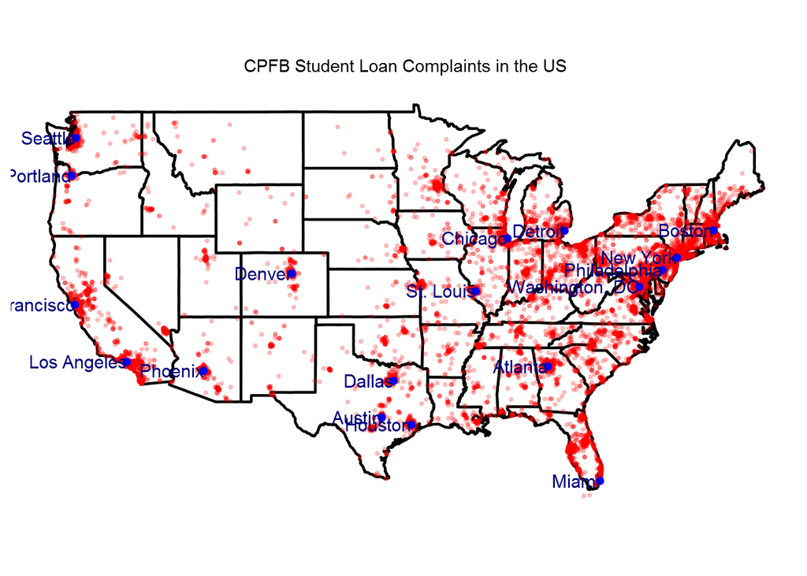

```r
ggplot() +
  geom_polygon(data=us, aes(group=group, x=long, y=lat), fill="white", col="black", size=.6) +
  geom_point(data=x[product=="Student loan"], aes(x=longitude, y=latitude), alpha=.2, size=.5, col="red", na.rm=T) +
  geom_point(data=bigCity, aes(x=lon, y=lat), col="blue") +
  geom_text(data=bigCity, aes(x=lon, y=lat, label=cityName, hjust=1), col="navyblue") +
  coord_map() +
  theme_map() + ggtitle("CPFB Student Loan Complaints in the US")
```

Not surprisingly, the majority of student loan complaints come from areas in or close to big cities, where most people with college degrees (and thus student loans) go to live/work.

How about mortgages? Instead of nationally, I am going to look at just one state, Illinois. In the dataset, there are 855 unique zipcodes for Illinois, but over 16,000 complaints. Since the location data (lat/long) only goes to the zipcode level, there are a lot of observations hidden if we look like this on a map. To overcome this, I can use the `jitter` function of `ggplot2` to put a slight random stagger in the points, which will give a better sense of the density of complaints.

Illinois Mortgage complaints

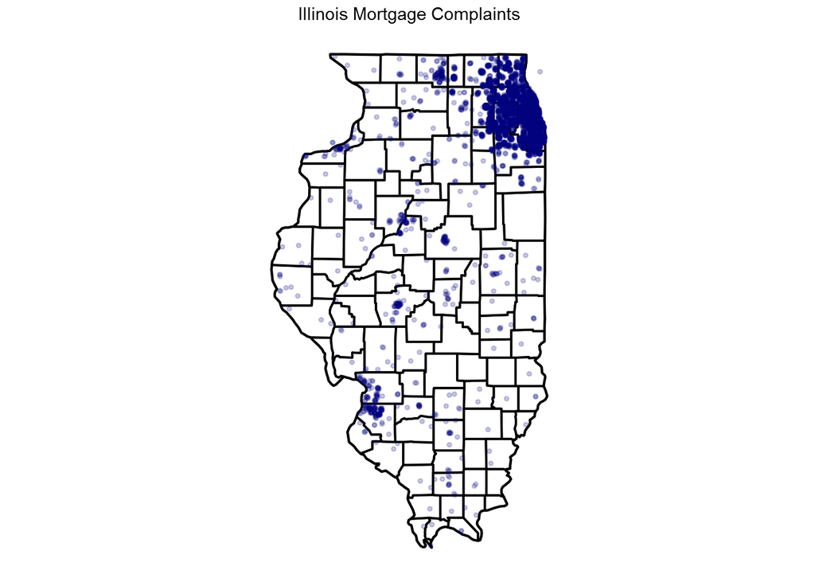

```r
ggplot() +
  geom_polygon(data=us[region=="illinois"], aes(x=long, y=lat, group=group), fill="white", col="black", size=.6) +
  geom_polygon(data=county[region=="illinois"], aes(x=long, y=lat, group=group), fill="white", col="black") +
  geom_jitter(data=x[state.y=="IL" & product=="Mortgage"],
              aes(x=longitude, y=latitude), size=.7, alpha=.2, col="navyblue", width=.04, height=.04) +
  coord_map() +
  theme_map() + ggtitle("Illinois Mortgage Complaints")
```

Unsurprsingly, the complaints are more dense where the population is more dense, which in Illinois is the Chicago metro area. To zoom in on that area, I am going to limit the map to the seven Chicagoland counties- Cook, McHenry, DuPage, Lake, Kane, Kendall, and Will. This is a more complicated process involving the `mgcv` package, which I was able to do thanks to my question being answered on [SO](http://stackoverflow.com/questions/39069936/limit-points-on-map-plot-to-one-layer/39070058#39070058).

After some considerable fiddling with the county dataset

```r
seven <- c("cook", "mchenry", "lake", "du page", "kane", "kendall", "will")

cnames <- as.data.table(aggregate(cbind(long, lat) ~ subregion, data=county[region=="illinois"],
                    FUN=function(x)mean(range(x))))

tmp <- lapply(split(county[region=="illinois" & subregion %in% seven, .(lat,long,subregion)], county[region=="illinois" & subregion %in% seven]$subregion), function(x) {
  bind_rows(list(x, data.frame(region=NA, lat=NA, long=NA)))
})

tmp <- bind_rows(tmp)

point.filter <- in.out(as.matrix(tmp[, c("lat","long")]),
                      as.matrix(x[state.y=="IL", .(latitude, longitude)]))
```

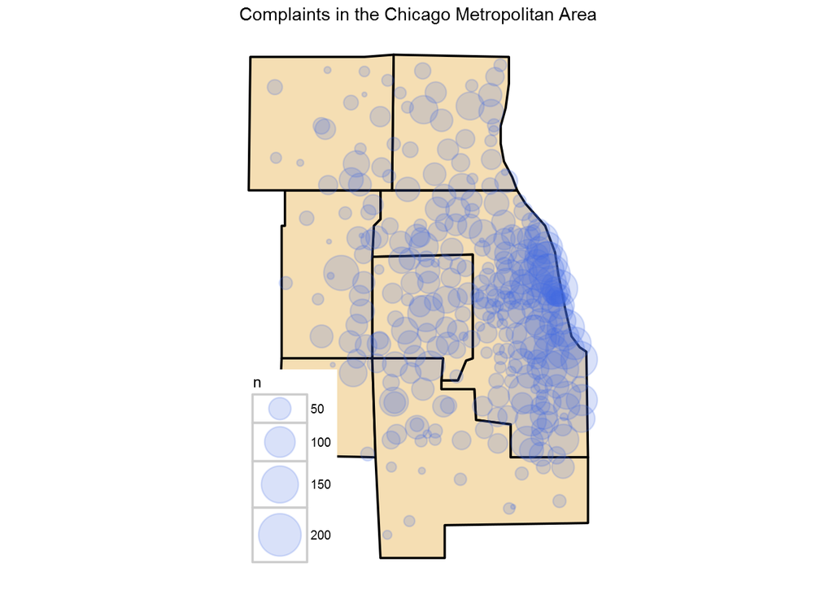

```r
ggplot() +
  geom_polygon(data=county[region=="illinois" & subregion %in% seven],
               aes(x=long, y=lat, group=group), fill="wheat", col="black") +
  geom_count(data=x[state.y=="IL"][point.filter], aes(x=longitude, y=latitude), alpha=.2, col="royalblue")+#, size=.1, width=.02, height=.02) +
  scale_size_area(max_size=12) +
  coord_map() +
  theme_map() + ggtitle("Complaints in the Chicago Metropolitan Area")
```